DS 6030 | Fall 2024 | University of Virginia

# Homework #0: Hello DS-6030

Author

**Benton Pelczynski**

Published

September 9, 2024

# Required R packages and Directories

```r
data_dir = 'https://mdporter.github.io/teaching/data/' # data directory
library(tidyverse) # functions for data manipulation
```

# Getting Help

The purpose of this (ungraded) homework is to help get you prepared for the semester. Don’t panic if you don’t immediately know the answers to some of these. I expect everyone will need to look things up. Take note of the areas that are rusty and plan to spend a bit of extra time to get up to speed. If some of these items are not even remotely familiar to you, then you probably have not satisfied the pre-requisite material; review the course syllabus and speak to me about any questions.

The teaching staff (TA and myself) are here to help! Don’t wait too long before asking for help and do let us know right away if you are starting to fall behind. I will also publish the solutions after due date. It is **highly encouraged** that you study the posted solutions.

# R Resources

## a. Update R, RStudio, and Quarto

- Use the latest version (R 4.4.1, RStudio 2024.04.2+764, Quarto 1.3.450)
- Installation help
  - R: https://cran.rstudio.com/
  - RStudio: https://posit.co/download/rstudio-desktop/
  - Quarto: https://quarto.org/docs/get-started/

## b. Install/Update the following packages we will meet during this course:

- Dynamic report generation: `rmarkdown`, `knitr`, `quarto`
- Utility: `remotes`
- Working with Data: `tidyverse`
- Data: `ISLR`, `moderndive`, `MASS`
- Resampling: `boot`, `rsample`
- Modeling: `tidymodels`, `modelr`, `broom`
- Regression: `glmnet`, `FNN`,
- Classification: `e1071`,
- Trees: `rpart`, `rpart.plot`, `randomForest`, `ranger`
- Ensembles: `gbm`, `xgboost`
- Density Estimation: `fitdistrplus`, `ks`
- Clustering: `mclust`, `mixtools`
- Association Analysis: `arules`
- Networks: `igraph`
- Forecasting: `fpp3`

You can see which of your existing packages need updating by running:

```r
old.packages() %>% as_tibble()
```

Or use the `update.packages()` function to update them.

Note: Do not call `install.packages()` in this Quarto document; it only needs to be done once from the console. However you will need to use `library()` in Quarto since it needs to be called every time the document is compiled.

## c. Install the course quarto extension

This document will not compile until you load the `ds6030hw-html` quarto extension. To do this, open a terminal window (if using RStudio, look for the terminal tab) and navigate to the same directory where this file is. Then run:

```
quarto add mdporter/quarto-ds6030-hw
```

which should create an `_extensions` directory (if connected to the internet). This contains the formatting for the compiled html document.

# Tidyverse Resources

Read the following sections in [R for Data Science 2e](https://r4ds.hadley.nz/):

- The Whole Game
  - Chapters 2-9
- Visualize
  - Chapters 10-12
- Transform
  - 12-15, 19
- Program
  - 26-27
- Communicate
  - 29

# Save/Bookmark the following cheatsheets and resources

[Posit Cheatsheets](https://posit.co/resources/cheatsheets/)

## **RStudio and Quarto**

- [RStudio IDE Cheatsheet](https://rstudio.github.io/cheatsheets/html/rstudio-ide.html)
- [Quarto Website](https://quarto.org/docs/authoring/markdown-basics.html)
- [Quarto Cheatsheet](https://rstudio.github.io/cheatsheets/html/quarto.html)
- [Latex Cheatsheet](https://wch.github.io/latexsheet/latexsheet-0.png)

## **R**

- [Base R](https://rstudio.github.io/cheatsheets/base-r.pdf)
- [Data Visualization Cheatsheet](https://rstudio.github.io/cheatsheets/html/data-visualization.html)
  - [`ggplot2` website](https://ggplot2.tidyverse.org/)
- [Tidy Data Cheatsheet](https://rstudio.github.io/cheatsheets/html/tidyr.html)
  - [`tidyr` website](https://tidyr.tidyverse.org/)
- [Data Transform Cheatsheet](https://rstudio.github.io/cheatsheets/html/data-transformation.html)
  - [`dplyr` website](https://dplyr.tidyverse.org/)
- [Factors with forcats Cheatsheet](https://rstudio.github.io/cheatsheets/html/factors.html)
  - [`forcats` website](https://forcats.tidyverse.org/)
- [Data Import Cheatsheet](https://rstudio.github.io/cheatsheets/html/data-import.html)
  - [`readr` website](https://readr.tidyverse.org/)
- [Apply Functions Cheatsheet](https://rstudio.github.io/cheatsheets/html/purrr.html)
  - [`purrr` website](https://purrr.tidyverse.org/)

## **Python with RStudio/RMarkdown** (Optional)

- [Python with R and Reticulate Cheatsheet](https://rstudio.github.io/cheatsheets/html/reticulate.html)

# Problem 1: Math Notation

## a. What are the equations for the least squares coefficients in linear regression (in matrix notation)? Use $X$ for the model/design/predictor matrix, and $Y$ the vector of outcomes.

**Solution**

$β = (X^TX)^{-1}X^TY$

## b. Let $x_1, x_2, \ldots, x_n$ be a sample of length of time that a customer is on the phone with a call center help line. We feel comfortable modeling the data as coming from an *exponential distribution*. What is the MLE (Maximum Likelihood Estimate) of the parameter? Show your steps.

**Solution**

1. Since the data is an exponential distribution, $f(x,θ) = θe^{-θx}$ for all $x \geq 0$
2. $L(θ) = \prod_{i=1}^nθe^{-θx_i}=θ^n\prod_{i=1}^ne^{-θx_i}$
3. $ln(L(θ)) = n(ln(θ))-θ\sum_{i=1}^nx_i$
4. $\frac{dln(L(θ))}{dθ}=\frac{n}{θ}-\sum_{i=1}^nx_i = 0$
5. $\frac{n}{θ}=\sum_{i=1}^nx_i$
6. $θ_{ML} = \frac{n}{\sum_{i=1}^nx_i}$

# Problem 2: Coding Practice

## a. Simulate 100 observations from the following model:

- $X \sim N(1, 1)$
- $Y \sim N(1 + 2X, 2)$
- $Z = \begin{cases} 1 &\quad Y<0 \\ 2 &\quad Y \ge 0 \end{cases}$

**Solution**

```r
X <- rnorm(100, 1, 1)
Y <- rnorm(100, 1+2*X, 2)
Z <- ifelse(Y < 0, 1, 2)
model_data <- data.frame(X,Y,Z)
model_data
```

```
          X       Y Z
1    1.8442  3.9601 2
2    2.2029  4.8595 2
3    1.0317  3.2937 2
4    1.2646  5.8552 2
5    1.3515  1.3456 2
6    0.1634  1.6406 2
7    3.9402  4.9713 2
8    1.6761  0.2212 2
9    1.3039  2.9561 2
10  -0.0574  0.7232 2
11  -1.8210 -2.0007 1
12   2.0967  7.2375 2
13   1.0763  1.5426 2
14   0.8984  6.1530 2
```

[output cut: 86 more lines]

## b. Make a scatter plot of the data. Put $X$ on the x-axis and $Y$ on the y-axis. Color the points according to $Z$.

**Solution**

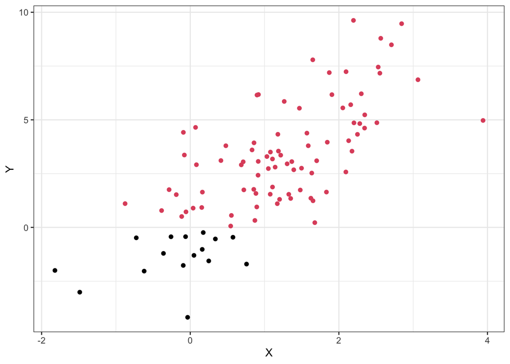

```r
ggplot(model_data, aes(x=X,y=Y))+geom_point(color=Z)
```

## c. Write a function that adds two numbers together and squares the result.

**Solution**

```r
add_and_square <- function(x, y){
  z <- x + y
  return (z**2)
}

add_and_square(2,3)
```

```
[1] 25
```

## d. Write a loop to calculate the mean of every column in (the built-in data) `mtcars`.

**Solution**

```r
for (col in mtcars) {
  print(mean(col))
}
```

```
[1] 20.1
[1] 6.19
[1] 231
[1] 147
[1] 3.6
[1] 3.22
[1] 17.8
[1] 0.438
[1] 0.406
[1] 3.69
[1] 2.81
```

# Problem 3: Statistics

## a. Find two [quantiles](https://en.wikipedia.org/wiki/Quantile) that capture 95% of the following data:

```r
set.seed(2022)
x = runif(n=100, min=2, max=22)
```

**Solution**

```r
quantile(x,c(.025,.975))
```

```
 2.5% 97.5%
 3.27 20.25
```

## b. Confidence Interval

A new machine learning model, developed by UVA researchers, uses biopsy images to predict if a child has enteropathy or celiac disease. [In a study of 102 patients](https://jamanetwork.com/journals/jamanetworkopen/fullarticle/2735765), the model was able to correctly classify 95 of the images.

Find the 90% [confidence interval](https://en.wikipedia.org/wiki/Confidence_interval) for the probability a patient is correctly classified?

**Solution**

```r
prop.test(95,102, conf.level = .9)
```

```
    1-sample proportions test with continuity correction

data:  95 out of 102, null probability 0.5
X-squared = 74, df = 1, p-value <2e-16
alternative hypothesis: true p is not equal to 0.5
90 percent confidence interval:
 0.872 0.966
sample estimates:
    p
0.931
```

The 90% confidence interval for the probability a patient is correctly classified is between 87.2% and 96.6%.

## c. Linear Models

- Albemarle County, VA real estate assessment data can be found [at this link](https://raw.githubusercontent.com/uvastatlab/phdplus/master/data/albemarle_homes.csv). Data collected by UVAs StatLab as part of the PhDplus program (https://github.com/uvastatlab/phdplus).
1. Fit a linear regression model that predicts the `totalvalue` using the predictors: `condition`, size (`finsqft`), and location (`city`).
2. What are the estimated coefficients?
3. What is the estimated `totalvalue` for home with the following characteristics?

| finsqft | city | condition |
| --- | --- | --- |
| 2500 | EARLYSVILLE | Good |
| 1850 | CROZET | Fair |

**Solution**

```r
estate_data = read.csv("https://raw.githubusercontent.com/uvastatlab/phdplus/master/data/albemarle_homes.csv")
est_model <- lm(totalvalue~condition+finsqft+city, data = estate_data)
summary(est_model)
```

```
Call:
lm(formula = totalvalue ~ condition + finsqft + city, data = estate_data)

Residuals:
     Min       1Q   Median       3Q      Max
-1065605   -83790   -18288    42699 11061827

Coefficients:
                      Estimate Std. Error t value Pr(>|t|)
(Intercept)          -1.43e+05   1.15e+04  -12.50  < 2e-16 ***
conditionExcellent    3.09e+04   5.64e+03    5.47  4.4e-08 ***
conditionFair         2.17e+04   8.54e+03    2.55  0.01091 *
conditionGood        -8.58e+03   3.13e+03   -2.74  0.00609 **
conditionNone        -8.50e+04   1.44e+04   -5.92  3.3e-09 ***
conditionPoor         1.75e+04   1.90e+04    0.92  0.35762
conditionSubstandard  1.07e+05   6.26e+04    1.71  0.08709 .
finsqft               2.74e+02   1.58e+00  173.38  < 2e-16 ***
cityBARBOURSVILLE    -2.08e+03   1.64e+04   -0.13  0.89918
cityCHARLOTTESVILLE  -2.14e+03   1.12e+04   -0.19  0.84778
cityCROZET           -2.55e+04   1.19e+04   -2.14  0.03213 *
cityEARLYSVILLE      -3.28e+04   1.24e+04   -2.64  0.00823 **
cityESMONT           -5.37e+04   1.54e+04   -3.47  0.00051 ***
cityKESWICK          -3.58e+04   1.27e+04   -2.82  0.00475 **
cityNORTH GARDEN     -3.18e+03   1.49e+04   -0.21  0.83094
cityOTHER             4.89e+04   1.24e+04    3.94  8.1e-05 ***
citySCOTTSVILLE      -4.20e+04   1.34e+04   -3.13  0.00172 **
---
Signif. codes:  0 '***' 0.001 '**' 0.01 '*' 0.05 '.' 0.1 ' ' 1

Residual standard error: 250000 on 32729 degrees of freedom
Multiple R-squared:  0.51,  Adjusted R-squared:  0.51
F-statistic: 2.13e+03 on 16 and 32729 DF,  p-value: <2e-16
```

```r
new_data <- data.frame(finsqft = c(2500, 1850),
       city = c('EARLYSVILLE', 'CROZET'),
       condition = c('Good', 'Fair'))
predict(est_model, newdata = new_data)
```

```
     1      2
500635 360076
```

## d. Hypothesis Testing

Use the `movies_sample` (IMDb) data from the `moderndive` R package to performance a hypothesis test that *Action* movies are ranked lower (on average) than *Romance* movies.

**Solution**

```r
library(moderndive)
t.test(rating ~ genre, data = movies_sample)
```

```
    Welch Two Sample t-test

data:  rating by genre
t = -3, df = 66, p-value = 0.005
alternative hypothesis: true difference in means between group Action and group Romance is not equal to 0
95 percent confidence interval:
 -1.767 -0.328
sample estimates:
 mean in group Action mean in group Romance
                 5.28                  6.32
```

Based on this t-test, we can conclude that *Action* movies are ranked lower on average than *Romance* movies.